# Krzysztof Jankowski HW3

## Dataset and models

### Dataset

Experiments are conducted on the 'pc1' dataset from OpenML which consists of data used for predicting software defects. The dataset consists of 21 features and 1109 samples. For each sample there is a true/false label associated with it indicating whether the software is defective or not. The dataset is imbalanced as can be seen on the histogram below.

### Models

I conduct the analysis on 2 models: RandomForest and LogisticRegression with the same hyperparameters tuned using grid search from homework 1. The hyperparameters are as follows:

- RandomForest: {'max_depth': 10, 'n_estimators': 1}
- LogisticRegression {'C': 0.01, 'penalty': 'l2', 'solver': 'liblinear'}

[figure not shown]

## Observations

I set a random seed for reproducibility and sample 2 observations from each class. The observations are as follows:

| loc | v(g) | ev(g) | iv(G) | N | V | L | D | I | E | B | T | lOCode | lOComment | locCodeAndComment | lOBlank | uniq_Op | uniq_Opnd | total_Op | total_Opnd | branchCount |
| --- | --- | --- | --- | --- | --- | --- | --- | --- | --- | --- | --- | --- | --- | --- | --- | --- | --- | --- | --- | --- |
| 107.0 | 25.0 | 7.0 | 14.0 | 619.0 | 4282.78 | 0.02 | 52.91 | 80.95 | 226588.75 | 1.43 | 12588.26 | 103.0 | 32.0 | 4.0 | 39.0 | 35.0 | 86.0 | 359.0 | 260.0 | 40.0 |
| 110.0 | 25.0 | 21.0 | 9.0 | 663.0 | 4404.88 | 0.02 | 45.10 | 97.66 | 198677.10 | 1.47 | 11037.62 | 97.0 | 23.0 | 13.0 | 37.0 | 23.0 | 77.0 | 361.0 | 302.0 | 49.0 |
| 8.0 | 3.0 | 1.0 | 3.0 | 41.0 | 160.18 | 0.06 | 17.00 | 9.42 | 2723.10 | 0.05 | 151.28 | 8.0 | 0.0 | 0.0 | 0.0 | 10.0 | 5.0 | 24.0 | 17.0 | 5.0 |
| 30.0 | 7.0 | 5.0 | 5.0 | 124.0 | 688.77 | 0.07 | 13.68 | 50.36 | 9420.58 | 0.23 | 523.37 | 29.0 | 0.0 | 1.0 | 11.0 | 16.0 | 31.0 | 71.0 | 53.0 | 13.0 |

first 2 observations have target 'true' and last 2 observations have target 'false'

### Models performance

Below I present the performance of both models on the whole dataset.

| model_name | recall | precision | f1 | accuracy | auc |
| --- | --- | --- | --- | --- | --- |
| RandomForestClassifier | 0.532468 | 0.745455 | 0.621212 | 0.954914 | 0.885671 |
| LogisticRegression | 0.181818 | 0.666667 | 0.285714 | 0.93688 | 0.700789 |

We can see that both models have similar accuracy, but the LogisticRegression has much lower recall and f1. It is most probably due to the high imbalance of the dataset.

Below I present the observations predictions for both models (incorrect predictions in bold).

| model_name | target_for_observation_1 | target_for_observation_2 | target_for_observation_3 | target_for_observation_4 |
| --- | --- | --- | --- | --- |
| RandomForest | 1 | 1 | 0 | 0 |
| LogisticRegression | **0** | **0** | 0 | 0 |
| Ground truth | 1 | 1 | 0 | 0 |

As mentioned above, LogisticRegression has very low recall and f1, therefore because it still has good accuracy, it more often predicts the '0' class and makes errors compared to a RandomForest.

## LIME

### Observations analysis.

I test LIME explanations on the same 4 observation using the RandomForest model. As lime uses randomness, to check the stability better, I run the analysis with 3 different random seeds and report the results below.

On the plot below each row contains explanation results for given observation with different random seeds (plot is big, so scrolling - vertical and horizontal might be necessary or zooming/downloading the png file).

[figure not shown]

We can see that LIME is quite stable as it comes to the first 2 most important features (in some cases even first 3 features). Starting with less important features, it tends to change the explanation with different seeds - the order is sometimes changed and the values change too as seen on the plot where sometimes some features are in red other times in green (e.g. D in observation 2). However, it is also worth noting that in case of this dataset the first 2-3 features dominate over all other features and therefore the importance difference between them and the rest is big. For these features it is also quite stable among all different observations as 2-3 most important feature names stay the same for all observations.

### Models comparison

I also compared the explanations of 4 sampled observations between 2 models: RandomForest and LogisticRegression. I report them below on the plot - each row contains explanations for given observation for both models.

[figure not shown]

## Dataset

```python
from sklearn.datasets import fetch_openml
import matplotlib.pyplot as plt
import os
import pandas as pd

X, y = fetch_openml('pc1', return_X_y=True)
# Convert y to 0/1
y = y.apply(lambda x: 1 if x == 'true' else 0)

pd.set_option('display.max_columns', None)

display(X.head())
print(y.head())
print('X shape ', X.shape)


# Create static directory if it does not exist.
if not os.path.exists('static'):
    os.makedirs('static')

# Visualization
plt.hist(y)
plt.title('Histogram of target classes')

# create directory static/models_comparison if it does not exist
if not os.path.exists('static/models_comparison'):
    os.makedirs('static/models_comparison')

plt.savefig('static/imbalance_plot.png')
plt.close()
```

|  | loc | v(g) | ev(g) | iv(G) | N | V | L | D | I | E | B | T | lOCode | lOComment | locCodeAndComment | lOBlank | uniq_Op | uniq_Opnd | total_Op | total_Opnd | branchCount |
| --- | --- | --- | --- | --- | --- | --- | --- | --- | --- | --- | --- | --- | --- | --- | --- | --- | --- | --- | --- | --- | --- |
| 0 | 1.1 | 1.4 | 1.4 | 1.4 | 1.3 | 1.30 | 1.30 | 1.30 | 1.30 | 1.30 | 1.30 | 1.30 | 2.0 | 2.0 | 2.0 | 2.0 | 1.2 | 1.2 | 1.2 | 1.2 | 1.4 |
| 1 | 1.0 | 1.0 | 1.0 | 1.0 | 1.0 | 1.00 | 1.00 | 1.00 | 1.00 | 1.00 | 1.00 | 1.00 | 1.0 | 1.0 | 1.0 | 1.0 | 1.0 | 1.0 | 1.0 | 1.0 | 1.0 |
| 2 | 91.0 | 9.0 | 3.0 | 2.0 | 318.0 | 2089.21 | 0.04 | 27.68 | 75.47 | 57833.24 | 0.70 | 3212.96 | 80.0 | 44.0 | 11.0 | 31.0 | 29.0 | 66.0 | 192.0 | 126.0 | 17.0 |
| 3 | 109.0 | 21.0 | 5.0 | 18.0 | 381.0 | 2547.56 | 0.04 | 28.37 | 89.79 | 72282.68 | 0.85 | 4015.70 | 97.0 | 41.0 | 12.0 | 24.0 | 28.0 | 75.0 | 229.0 | 152.0 | 38.0 |
| 4 | 505.0 | 106.0 | 41.0 | 82.0 | 2339.0 | 20696.93 | 0.01 | 75.93 | 272.58 | 1571506.88 | 6.90 | 87305.94 | 457.0 | 71.0 | 48.0 | 49.0 | 64.0 | 397.0 | 1397.0 | 942.0 | 178.0 |

```
0    0
1    1
2    1
3    1
4    1
Name: defects, dtype: category
Categories (2, int64): [0, 1]
X shape  (1109, 21)
```

## Models

```python
# # Uncomment if you do not have this libraries installed
# !pip install dalex
# !pip install lime
```

```python
from sklearn.linear_model import LogisticRegression
from sklearn.ensemble import RandomForestClassifier
import dalex as dx

models_dict = {
    'RandomForest': RandomForestClassifier(random_state=42, max_depth=10, n_estimators=1),
    'LogisticRegression': LogisticRegression(random_state=42, C=0.01, penalty='l2', solver='liblinear')
}

explainers = {}
for model_name, model in models_dict.items():
    model.fit(X, y)
    explainer = dx.Explainer(model, X, y)
    print(f'Model {model_name} performance')
    display(explainer.model_performance())
    # save for further use
    explainers[model_name] = explainer
```

```
Preparation of a new explainer is initiated

  -> data              : 1109 rows 21 cols
  -> target variable   : Parameter 'y' was a pandas.Series. Converted to a numpy.ndarray.
  -> target variable   : 1109 values
  -> model_class       : sklearn.ensemble._forest.RandomForestClassifier (default)
  -> label             : Not specified, model's class short name will be used. (default)
  -> predict function  : <function yhat_proba_default at 0x7f256c9b2290> will be used (default)
  -> predict function  : Accepts pandas.DataFrame and numpy.ndarray.
  -> predicted values  : min = 0.0, mean = 0.0762, max = 1.0
  -> model type        : classification will be used (default)
  -> residual function : difference between y and yhat (default)
  -> residuals         : min = -1.0, mean = -0.00677, max = 1.0
  -> model_info        : package sklearn

A new explainer has been created!
Model RandomForest performance
```

|  | recall | precision | f1 | accuracy | auc |
| --- | --- | --- | --- | --- | --- |
| RandomForestClassifier | 0.532468 | 0.745455 | 0.621212 | 0.954914 | 0.885671 |

```
Preparation of a new explainer is initiated

  -> data              : 1109 rows 21 cols
  -> target variable   : Parameter 'y' was a pandas.Series. Converted to a numpy.ndarray.
  -> target variable   : 1109 values
  -> model_class       : sklearn.linear_model._logistic.LogisticRegression (default)
  -> label             : Not specified, model's class short name will be used. (default)
  -> predict function  : <function yhat_proba_default at 0x7f256c9b2290> will be used (default)
  -> predict function  : Accepts pandas.DataFrame and numpy.ndarray.
  -> predicted values  : min = 2.32e-32, mean = 0.0923, max = 1.0
  -> model type        : classification will be used (default)
  -> residual function : difference between y and yhat (default)
  -> residuals         : min = -0.957, mean = -0.0229, max = 0.979
  -> model_info        : package sklearn

A new explainer has been created!
Model LogisticRegression performance
```

|  | recall | precision | f1 | accuracy | auc |
| --- | --- | --- | --- | --- | --- |
| LogisticRegression | 0.181818 | 0.666667 | 0.285714 | 0.93688 | 0.700789 |

### Observations

```python
import pandas as pd
import numpy as np

# set seed for reproducibility
np.random.seed(42)

observations_with_target_true = X[y == 1]
observations_with_target_false = X[y == 0]

# sample 2 observations randomly from each class
sampled_observations = pd.concat([observations_with_target_true.sample(2), observations_with_target_false.sample(2)])
display(sampled_observations)

for model_name, model in models_dict.items():
    print(f'Model {model_name} predictions')
    print(model.predict(sampled_observations))
```

|  | loc | v(g) | ev(g) | iv(G) | N | V | L | D | I | E | B | T | lOCode | lOComment | locCodeAndComment | lOBlank | uniq_Op | uniq_Opnd | total_Op | total_Opnd | branchCount |
| --- | --- | --- | --- | --- | --- | --- | --- | --- | --- | --- | --- | --- | --- | --- | --- | --- | --- | --- | --- | --- | --- |
| 5 | 107.0 | 25.0 | 7.0 | 14.0 | 619.0 | 4282.78 | 0.02 | 52.91 | 80.95 | 226588.75 | 1.43 | 12588.26 | 103.0 | 32.0 | 4.0 | 39.0 | 35.0 | 86.0 | 359.0 | 260.0 | 40.0 |
| 36 | 110.0 | 25.0 | 21.0 | 9.0 | 663.0 | 4404.88 | 0.02 | 45.10 | 97.66 | 198677.10 | 1.47 | 11037.62 | 97.0 | 23.0 | 13.0 | 37.0 | 23.0 | 77.0 | 361.0 | 302.0 | 49.0 |
| 559 | 8.0 | 3.0 | 1.0 | 3.0 | 41.0 | 160.18 | 0.06 | 17.00 | 9.42 | 2723.10 | 0.05 | 151.28 | 8.0 | 0.0 | 0.0 | 0.0 | 10.0 | 5.0 | 24.0 | 17.0 | 5.0 |
| 216 | 30.0 | 7.0 | 5.0 | 5.0 | 124.0 | 688.77 | 0.07 | 13.68 | 50.36 | 9420.58 | 0.23 | 523.37 | 29.0 | 0.0 | 1.0 | 11.0 | 16.0 | 31.0 | 71.0 | 53.0 | 13.0 |

```
Model RandomForest predictions
[1 1 0 0]
Model LogisticRegression predictions
[0 0 0 0]
```

### LIME

#### LIME for Random Forest and different seeds in observations

```
Testing with numpy seed 0.
Testing with numpy seed 1.
Testing with numpy seed 2.
```

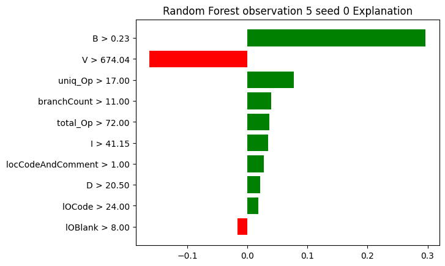

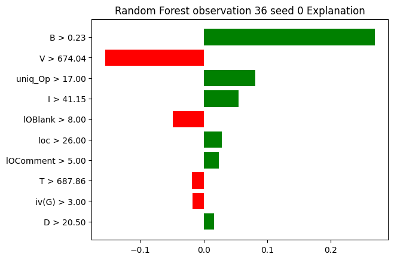

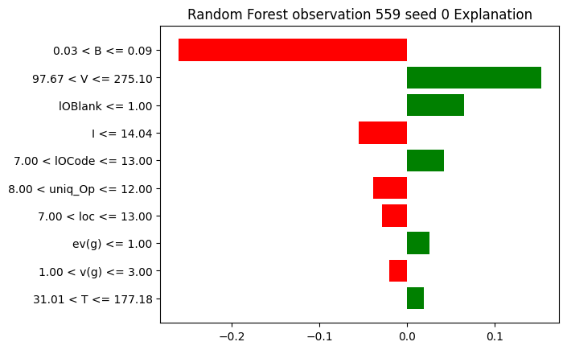

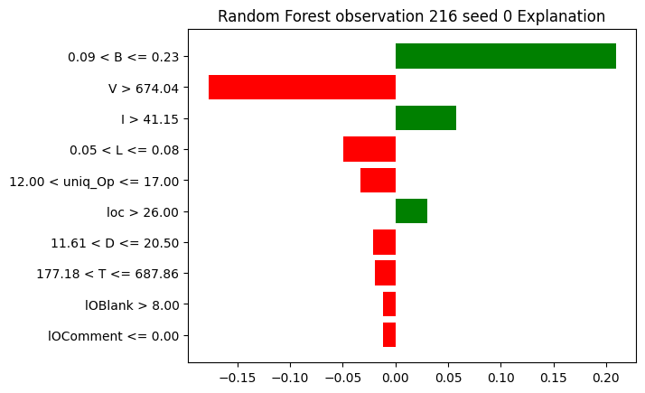

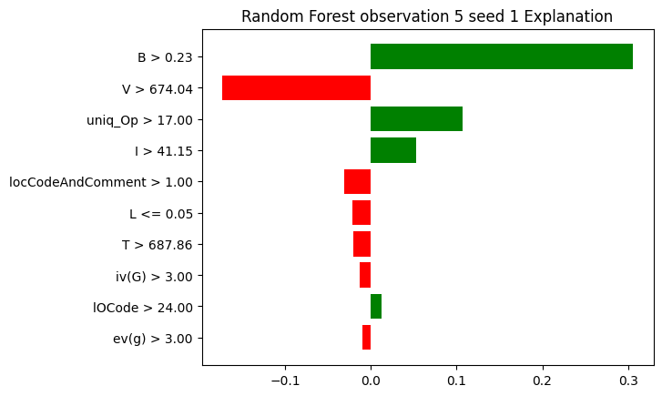

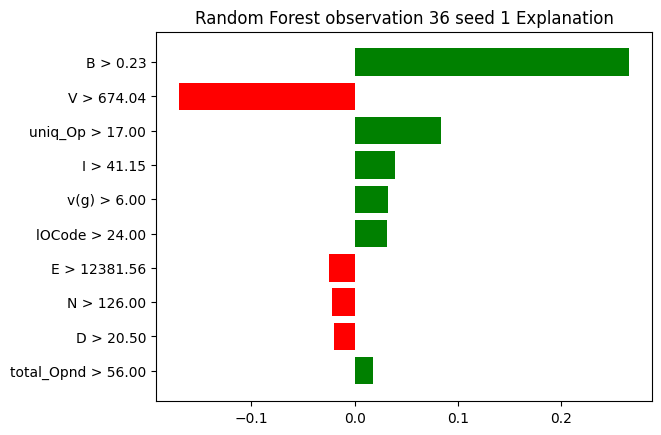

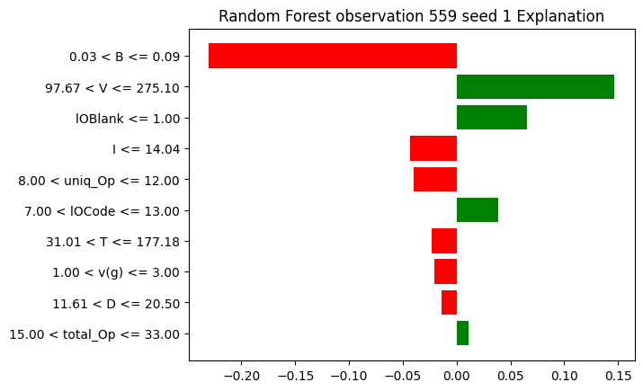

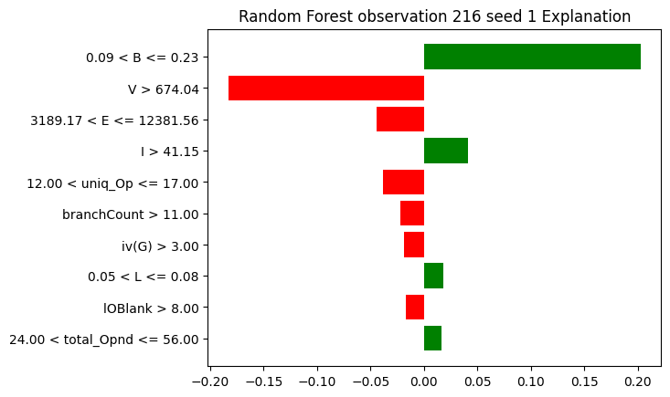

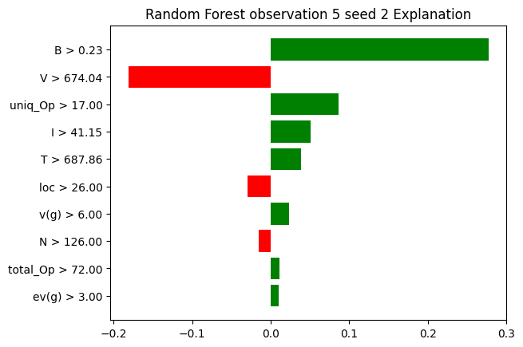

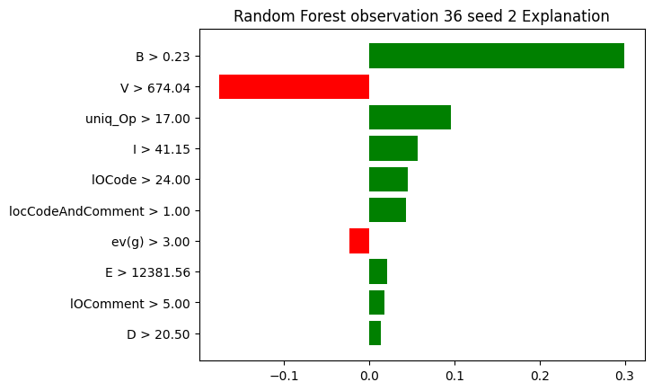

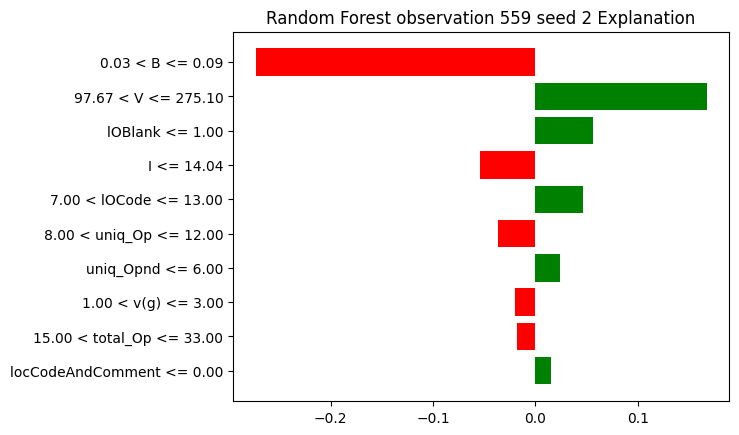

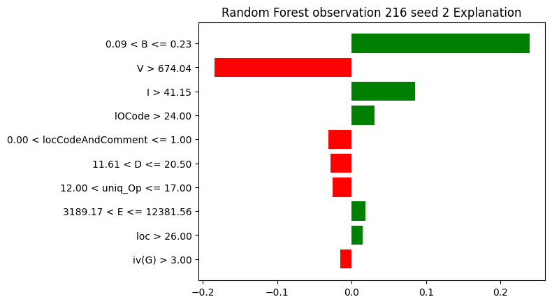

```python
from pathlib import Path

numpy_seeds = [0, 1, 2]
explainer = explainers['RandomForest']
output_dir = 'static/observations_comparison'

# Create directory if it does not exist
if not os.path.exists(output_dir):
    os.makedirs(output_dir)

for numpy_seed in numpy_seeds:
    print(f'Testing with numpy seed {numpy_seed}.')
    np.random.seed(numpy_seed)
    for c, (index, row) in enumerate(sampled_observations.iterrows()):
        observation = row.to_numpy().reshape(1, -1)
        explanation = explainer.predict_surrogate(observation)
        explanation.plot()
        plt.title(f'Random Forest observation {index} seed {numpy_seed} Explanation')
        plt.savefig(Path(output_dir) / f'observation_{index}_random_forest_seed_{numpy_seed}.png', bbox_inches='tight')
```

#### LIME for models comparison

```
Observation 5
Model RandomForest explanation
Model LogisticRegression explanation
Observation 36
Model RandomForest explanation
Model LogisticRegression explanation
Observation 559
Model RandomForest explanation
Model LogisticRegression explanation
Observation 216
Model RandomForest explanation
Model LogisticRegression explanation
```

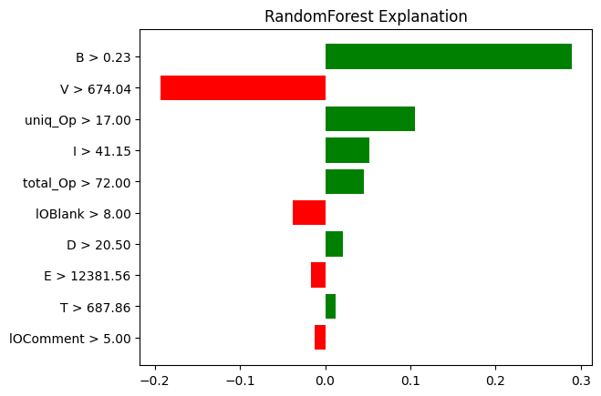

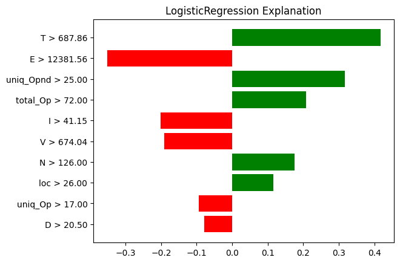

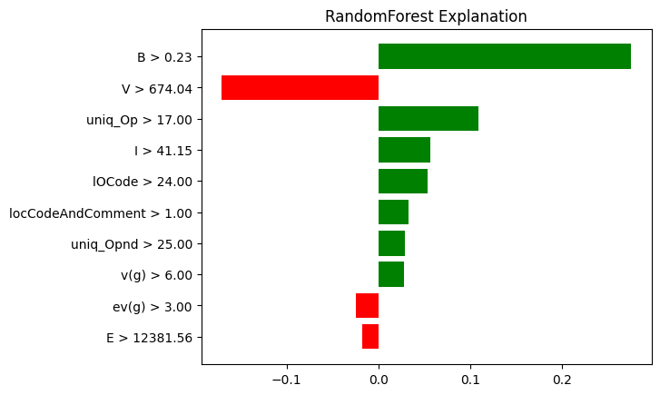

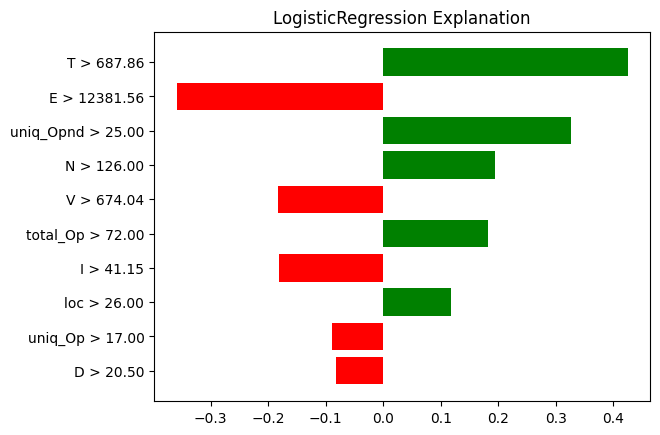

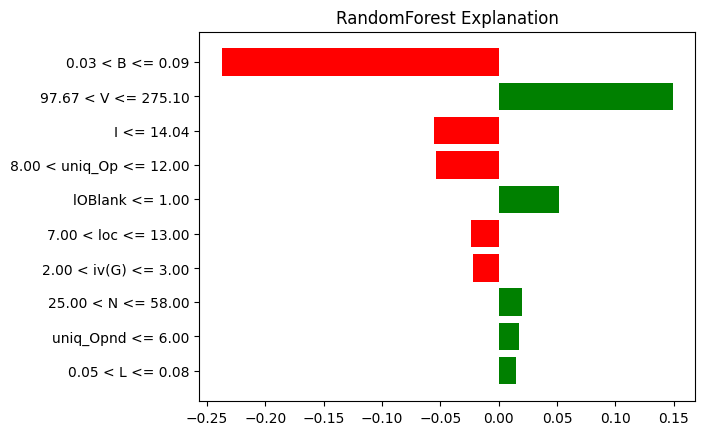

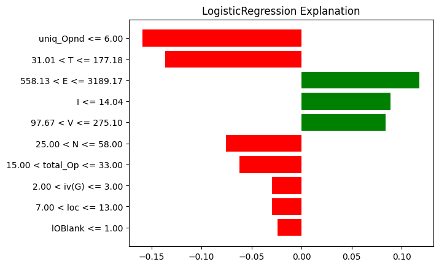

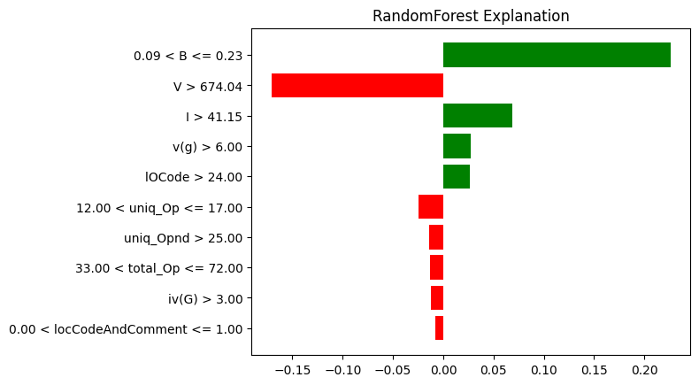

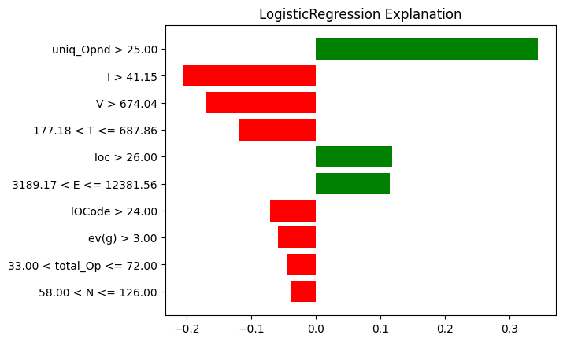

```python
import matplotlib.pyplot as plt
import os

output_dir = 'static/models_comparison'

# create directory static/models_comparison if it does not exist
if not os.path.exists(output_dir):
    os.makedirs(output_dir)

np.random.seed(42)
for c, (index, row) in enumerate(sampled_observations.iterrows()):
    print(f'Observation {index}')
    for i, (model_name, explainer) in enumerate(explainers.items()):
        print(f'Model {model_name} explanation')
        observation = row.to_numpy().reshape(1, -1)
        explanation = explainer.predict_surrogate(observation)
        explanation.plot()
        plt.title(f'{model_name} Explanation')
        plt.savefig(Path(output_dir) / f'observation_{index}_{model_name}_explanation_{c}.png', bbox_inches='tight')
```

### Utils for combining images into a grid for the report

```python
from PIL import Image
import os

def combine_pngs_into_grid(input_directory: str, num_cols: int, output_filename: str):
    # List all PNG files in the directory
    png_files = [f for f in os.listdir(input_directory) if f.endswith('.png')]
    png_files.sort()
    images = []

    for png_file in png_files:
        image = Image.open(os.path.join(input_directory, png_file))
        images.append(image)

    num_rows = (len(images) + num_cols - 1) // num_cols

    # Create a new blank image for the grid with color white as background
    grid_width = max(image.width for image in images) * num_cols
    grid_height = sum(image.height for image in images[:num_rows])
    grid = Image.new('RGB', (grid_width, grid_height), color='white')

    # Paste the images into the grid
    x, y = 0, 0
    for i, image in enumerate(images):
        grid.paste(image, (x, y))
        x += image.width
        if i % num_cols == num_cols - 1:
            x = 0
            y += image.height

    # Display and save the final grid image
    grid.show()
    grid.save(output_filename)
```

```python
combine_pngs_into_grid('static/models_comparison', 2, 'static/models_comparison.png')
```

```python
combine_pngs_into_grid('static/observations_comparison', 3, 'static/observations_comparison.png')
```